# Bellabeat Case Study in R

Sahil Chikode

2025-08-08

## About Company

Urska Srsen and Sando Mur founded Bellabeat, a high-tech company that manufactures health-focused sma products.Srsen used her background as an a ist to develop beautifully designed technology that informs and inspires women around the world. Collecting data on activity, sleep, stress, and reproductive health has allowed Bellabeat to empower women with knowledge about their own health and habits. Since it was founded in 2013, Bellabeat has grown rapidly and quickly positioned itself as a tech-driven wellness company for women. By 2016, Bellabeat had opened offices around the world and launched multiple products. Bellabeat products became available through a growing number of online retailers in addition to their own e-commerce channel on their websitehttps://bellabeat.com/.

## Question for the analysis

1. What are some trends in sma device usage?
2. How could these trends apply to Bellabeat customers?
3. How could these trends help in influence Bellabeat marketing strategy?

## Loading Packages

```r
library(tidyverse)
```

```r
library(dplyr)
library(ggplot2)
library(tidyr)
library(janitor)
library(skimr)
```

```r
daily_activity <- read.csv("C:/Users/Admin/OneDrive/Desktop/PROJECTS/Bellabeat/Fitabase Data/dailyActivity_merged.csv")
sleep <- read.csv("C:/Users/Admin/OneDrive/Desktop/PROJECTS/Bellabeat/Fitabase Data/SleepDay_merged.csv")
weight <- read.csv("C:/Users/Admin/OneDrive/Desktop/PROJECTS/Bellabeat/Fitabase Data/weightLogInfo_merged.csv")
calories <- read.csv("C:/Users/Admin/OneDrive/Desktop/PROJECTS/Bellabeat/Fitabase Data/hourlyCalories_merged.csv")
intensities <- read.csv("C:/Users/Admin/OneDrive/Desktop/PROJECTS/Bellabeat/Fitabase Data/hourlyIntensities_merged.csv")
```

```r
head(daily_activity)
```

```
##           Id ActivityDate TotalSteps TotalDistance TrackerDistance
## 1 1503960366    3/25/2016      11004          7.11            7.11
## 2 1503960366    3/26/2016      17609         11.55           11.55
## 3 1503960366    3/27/2016      12736          8.53            8.53
## 4 1503960366    3/28/2016      13231          8.93            8.93
## 5 1503960366    3/29/2016      12041          7.85            7.85
## 6 1503960366    3/30/2016      10970          7.16            7.16
##   LoggedActivitiesDistance VeryActiveDistance ModeratelyActiveDistance
## 1                        0               2.57                     0.46
## 2                        0               6.92                     0.73
## 3                        0               4.66                     0.16
## 4                        0               3.19                     0.79
## 5                        0               2.16                     1.09
## 6                        0               2.36                     0.51
##   LightActiveDistance SedentaryActiveDistance VeryActiveMinutes
## 1                4.07                       0                33
## 2                3.91                       0                89
## 3                3.71                       0                56
## 4                4.95                       0                39
## 5                4.61                       0                28
## 6                4.29                       0                30
##   FairlyActiveMinutes LightlyActiveMinutes SedentaryMinutes Calories
## 1                  12                  205              804     1819
## 2                  17                  274              588     2154
## 3                   5                  268              605     1944
## 4                  20                  224             1080     1932
## 5                  28                  243              763     1886
## 6                  13                  223             1174     1820
```

```r
head(sleep)
```

```
##           Id              SleepDay TotalSleepRecords TotalMinutesAsleep
## 1 1503960366 4/12/2016 12:00:00 AM                 1                327
## 2 1503960366 4/13/2016 12:00:00 AM                 2                384
## 3 1503960366 4/15/2016 12:00:00 AM                 1                412
## 4 1503960366 4/16/2016 12:00:00 AM                 2                340
## 5 1503960366 4/17/2016 12:00:00 AM                 1                700
## 6 1503960366 4/19/2016 12:00:00 AM                 1                304
##   TotalTimeInBed
## 1            346
## 2            407
## 3            442
## 4            367
## 5            712
## 6            320
```

## Fixing formating of the date

```r
# intensities
intensities$ActivityHour=as.POSIXct(intensities$ActivityHour, format="%m/%d/%Y %I:%M:%S %p", tz=Sys.timezone())
intensities$time <- format(intensities$ActivityHour, format = "%H:%M:%S")
intensities$date <- format(intensities$ActivityHour, format = "%m/%d/%y")
# calories
calories$ActivityHour=as.POSIXct(calories$ActivityHour, format="%m/%d/%Y %I:%M:%S %p", tz=Sys.timezone())
calories$time <- format(calories$ActivityHour, format = "%H:%M:%S")
calories$date <- format(calories$ActivityHour, format = "%m/%d/%y")
# activity
daily_activity$ActivityDate=as.POSIXct(daily_activity$ActivityDate, format="%m/%d/%Y", tz=Sys.timezone())
daily_activity$date <- format(daily_activity$ActivityDate, format = "%m/%d/%y")
# sleep
sleep$SleepDay=as.POSIXct(sleep$SleepDay, format="%m/%d/%Y %I:%M:%S %p", tz=Sys.timezone())
sleep$date <- format(sleep$SleepDay, format = "%m/%d/%y")
#weight
weight$Date=as.POSIXct(weight$Date, format="%m/%d/%Y %I:%M:%S %p", tz=Sys.timezone())
weight$time <- format(weight$Date, format = "%H:%M:%S")
weight$date <- format(weight$Date, format = "%m/%d/%y")
```

The format of data and time is not consistent accross all the dataset. So, I can converted the into single format.

## Summarizing the data.

```r
skim_without_charts(daily_activity)
```

Data summary

| Name | daily_activity |
| --- | --- |
| Number of rows | 457 |
| Number of columns | 16 |
| _______________________ |  |
| Column type frequency: |  |
| character | 1 |
| numeric | 14 |
| POSIXct | 1 |
| ________________________ |  |
| Group variables | None |

**Variable type: character**

| skim_variable | n_missing | complete_rate | min | max | empty | n_unique | whitespace |
| --- | --- | --- | --- | --- | --- | --- | --- |
| date | 0 | 1 | 8 | 8 | 0 | 32 | 0 |

**Variable type: numeric**

| skim_variable | n_missing | complete_rate | mean | sd | p0 | p25 | p50 | p75 | p100 |
| --- | --- | --- | --- | --- | --- | --- | --- | --- | --- |
| Id | 0 | 1 | 4.628595e+09 | 2.293781e+09 | 1503960366 | 2.347168e+09 | 4.057193e+09 | 6.391747e+09 | 8.877689e+09 |
| TotalSteps | 0 | 1 | 6.546560e+03 | 5.398490e+03 | 0 | 1.988000e+03 | 5.986000e+03 | 1.019800e+04 | 2.849700e+04 |
| TotalDistance | 0 | 1 | 4.660000e+00 | 4.080000e+00 | 0 | 1.410000e+00 | 4.090000e+00 | 7.160000e+00 | 2.753000e+01 |
| TrackerDistance | 0 | 1 | 4.610000e+00 | 4.070000e+00 | 0 | 1.280000e+00 | 4.090000e+00 | 7.110000e+00 | 2.753000e+01 |
| LoggedActivitiesDistance | 0 | 1 | 1.800000e-01 | 8.500000e-01 | 0 | 0.000000e+00 | 0.000000e+00 | 0.000000e+00 | 6.730000e+00 |
| VeryActiveDistance | 0 | 1 | 1.180000e+00 | 2.490000e+00 | 0 | 0.000000e+00 | 0.000000e+00 | 1.310000e+00 | 2.192000e+01 |
| ModeratelyActiveDistance | 0 | 1 | 4.800000e-01 | 8.300000e-01 | 0 | 0.000000e+00 | 2.000000e-02 | 6.700000e-01 | 6.400000e+00 |
| LightActiveDistance | 0 | 1 | 2.890000e+00 | 2.240000e+00 | 0 | 8.700000e-01 | 2.930000e+00 | 4.460000e+00 | 1.251000e+01 |
| SedentaryActiveDistance | 0 | 1 | 0.000000e+00 | 1.000000e-02 | 0 | 0.000000e+00 | 0.000000e+00 | 0.000000e+00 | 1.000000e-01 |
| VeryActiveMinutes | 0 | 1 | 1.662000e+01 | 2.892000e+01 | 0 | 0.000000e+00 | 0.000000e+00 | 2.500000e+01 | 2.020000e+02 |
| FairlyActiveMinutes | 0 | 1 | 1.307000e+01 | 3.621000e+01 | 0 | 0.000000e+00 | 1.000000e+00 | 1.600000e+01 | 6.600000e+02 |
| LightlyActiveMinutes | 0 | 1 | 1.700700e+02 | 1.222100e+02 | 0 | 6.400000e+01 | 1.810000e+02 | 2.570000e+02 | 7.200000e+02 |
| SedentaryMinutes | 0 | 1 | 9.952800e+02 | 3.370200e+02 | 32 | 7.280000e+02 | 1.057000e+03 | 1.285000e+03 | 1.440000e+03 |
| Calories | 0 | 1 | 2.189450e+03 | 8.154800e+02 | 0 | 1.776000e+03 | 2.062000e+03 | 2.667000e+03 | 4.562000e+03 |

**Variable type: POSIXct**

| skim_variable | n_missing | complete_rate | min | max | median | n_unique |
| --- | --- | --- | --- | --- | --- | --- |
| ActivityDate | 0 | 1 | 2016-03-12 | 2016-04-12 | 2016-04-05 | 32 |

```r
skim_without_charts(sleep)
```

Data summary

| Name | sleep |
| --- | --- |
| Number of rows | 413 |
| Number of columns | 6 |
| _______________________ |  |
| Column type frequency: |  |
| character | 1 |
| numeric | 4 |
| POSIXct | 1 |
| ________________________ |  |
| Group variables | None |

**Variable type: character**

| skim_variable | n_missing | complete_rate | min | max | empty | n_unique | whitespace |
| --- | --- | --- | --- | --- | --- | --- | --- |
| date | 0 | 1 | 8 | 8 | 0 | 31 | 0 |

**Variable type: numeric**

| skim_variable | n_missing | complete_rate | mean | sd | p0 | p25 | p50 | p75 | p100 |
| --- | --- | --- | --- | --- | --- | --- | --- | --- | --- |
| Id | 0 | 1 | 5.000979e+09 | 2.06036e+09 | 1503960366 | 3977333714 | 4702921684 | 6962181067 | 8792009665 |
| TotalSleepRecords | 0 | 1 | 1.120000e+00 | 3.50000e-01 | 1 | 1 | 1 | 1 | 3 |
| TotalMinutesAsleep | 0 | 1 | 4.194700e+02 | 1.18340e+02 | 58 | 361 | 433 | 490 | 796 |
| TotalTimeInBed | 0 | 1 | 4.586400e+02 | 1.27100e+02 | 61 | 403 | 463 | 526 | 961 |

**Variable type: POSIXct**

| skim_variable | n_missing | complete_rate | min | max | median | n_unique |
| --- | --- | --- | --- | --- | --- | --- |
| SleepDay | 0 | 1 | 2016-04-12 | 2016-05-12 | 2016-04-27 | 31 |

```r
skim_without_charts(weight)
```

Data summary

| Name | weight |
| --- | --- |
| Number of rows | 33 |
| Number of columns | 10 |
| _______________________ |  |
| Column type frequency: |  |
| character | 3 |
| numeric | 6 |
| POSIXct | 1 |
| ________________________ |  |
| Group variables | None |

**Variable type: character**

| skim_variable | n_missing | complete_rate | min | max | empty | n_unique | whitespace |
| --- | --- | --- | --- | --- | --- | --- | --- |
| IsManualReport | 0 | 1 | 4 | 5 | 0 | 2 | 0 |
| time | 0 | 1 | 8 | 8 | 0 | 11 | 0 |
| date | 0 | 1 | 8 | 8 | 0 | 14 | 0 |

**Variable type: numeric**

| skim_variable | n_missing | complete_rate | mean | sd | p0 | p25 | p50 | p75 | p100 |
| --- | --- | --- | --- | --- | --- | --- | --- | --- | --- |
| Id | 0 | 1.00 | 6.477156e+09 | 2.308888e+09 | 1.503960e+09 | 4.702922e+09 | 6.962181e+09 | 8.877689e+09 | 8.877689e+09 |
| WeightKg | 0 | 1.00 | 7.344000e+01 | 1.653000e+01 | 5.330000e+01 | 6.170000e+01 | 6.250000e+01 | 8.580000e+01 | 1.296000e+02 |
| WeightPounds | 0 | 1.00 | 1.619100e+02 | 3.644000e+01 | 1.175100e+02 | 1.360300e+02 | 1.377900e+02 | 1.891600e+02 | 2.857200e+02 |
| Fat | 31 | 0.06 | 1.600000e+01 | 8.490000e+00 | 1.000000e+01 | 1.300000e+01 | 1.600000e+01 | 1.900000e+01 | 2.200000e+01 |
| BMI | 0 | 1.00 | 2.573000e+01 | 4.330000e+00 | 2.145000e+01 | 2.410000e+01 | 2.439000e+01 | 2.576000e+01 | 4.617000e+01 |
| LogId | 0 | 1.00 | 1.459959e+12 | 3.088072e+08 | 1.459382e+12 | 1.459753e+12 | 1.459987e+12 | 1.460160e+12 | 1.460506e+12 |

**Variable type: POSIXct**

| skim_variable | n_missing | complete_rate | min | max | median | n_unique |
| --- | --- | --- | --- | --- | --- | --- |
| Date | 0 | 1 | 2016-03-30 23:59:59 | 2016-04-12 23:59:59 | 2016-04-06 23:59:59 | 24 |

```r
skim_without_charts(calories)
```

Data summary

| Name | calories |
| --- | --- |
| Number of rows | 24084 |
| Number of columns | 5 |
| _______________________ |  |
| Column type frequency: |  |
| character | 2 |
| numeric | 2 |
| POSIXct | 1 |
| ________________________ |  |
| Group variables | None |

**Variable type: character**

| skim_variable | n_missing | complete_rate | min | max | empty | n_unique | whitespace |
| --- | --- | --- | --- | --- | --- | --- | --- |
| time | 0 | 1 | 8 | 8 | 0 | 24 | 0 |
| date | 0 | 1 | 8 | 8 | 0 | 32 | 0 |

**Variable type: numeric**

| skim_variable | n_missing | complete_rate | mean | sd | p0 | p25 | p50 | p75 | p100 |
| --- | --- | --- | --- | --- | --- | --- | --- | --- | --- |
| Id | 0 | 1 | 4.889424e+09 | 2421565819.2 | 1503960366 | 2347167796 | 4558609924 | 6962181067 | 8877689391 |
| Calories | 0 | 1 | 9.427000e+01 | 59.4 | 42 | 61 | 77 | 104 | 933 |

**Variable type: POSIXct**

| skim_variable | n_missing | complete_rate | min | max | median | n_unique |
| --- | --- | --- | --- | --- | --- | --- |
| ActivityHour | 0 | 1 | 2016-03-12 | 2016-04-12 10:00:00 | 2016-03-27 04:00:00 | 755 |

```r
skim_without_charts(intensities)
```

Data summary

| Name | intensities |
| --- | --- |
| Number of rows | 24084 |
| Number of columns | 6 |
| _______________________ |  |
| Column type frequency: |  |
| character | 2 |
| numeric | 3 |
| POSIXct | 1 |
| ________________________ |  |
| Group variables | None |

**Variable type: character**

| skim_variable | n_missing | complete_rate | min | max | empty | n_unique | whitespace |
| --- | --- | --- | --- | --- | --- | --- | --- |
| time | 0 | 1 | 8 | 8 | 0 | 24 | 0 |
| date | 0 | 1 | 8 | 8 | 0 | 32 | 0 |

**Variable type: numeric**

| skim_variable | n_missing | complete_rate | mean | sd | p0 | p25 | p50 | p75 | p100 |
| --- | --- | --- | --- | --- | --- | --- | --- | --- | --- |
| Id | 0 | 1 | 4.889424e+09 | 2.421566e+09 | 1503960366 | 2347167796 | 4.55861e+09 | 6.962181e+09 | 8877689391 |
| TotalIntensity | 0 | 1 | 1.083000e+01 | 2.031000e+01 | 0 | 0 | 1.00000e+00 | 1.400000e+01 | 180 |
| AverageIntensity | 0 | 1 | 1.800000e-01 | 3.400000e-01 | 0 | 0 | 2.00000e-02 | 2.300000e-01 | 3 |

**Variable type: POSIXct**

| skim_variable | n_missing | complete_rate | min | max | median | n_unique |
| --- | --- | --- | --- | --- | --- | --- |
| ActivityHour | 0 | 1 | 2016-03-12 | 2016-04-12 10:00:00 | 2016-03-27 04:00:00 | 755 |

Using library skimr, summarize each dataset without chart.

```r
n_distinct(daily_activity$Id)
```

```
## [1] 35
```

```r
n_distinct(sleep$Id)
```

```
## [1] 24
```

```r
n_distinct(weight$Id)
```

```
## [1] 11
```

```r
n_distinct(intensities$Id)
```

```
## [1] 34
```

```r
n_distinct(calories$Id)
```

```
## [1] 34
```

This is about number participants in each data sets. There are 35 participants in daily activity data set, 34 participants in intensities and calories data set, 24 in sleep data set and 11 at weight data set.

Now summary statistics of all the data sets.

```r
daily_activity %>% select(Id, TotalSteps, TotalDistance, SedentaryMinutes) %>%
  summary()
```

```
##        Id              TotalSteps    TotalDistance    SedentaryMinutes
##  Min.   :1.504e+09   Min.   :    0   Min.   : 0.000   Min.   :  32.0
##  1st Qu.:2.347e+09   1st Qu.: 1988   1st Qu.: 1.410   1st Qu.: 728.0
##  Median :4.057e+09   Median : 5986   Median : 4.090   Median :1057.0
##  Mean   :4.629e+09   Mean   : 6547   Mean   : 4.664   Mean   : 995.3
##  3rd Qu.:6.392e+09   3rd Qu.:10198   3rd Qu.: 7.160   3rd Qu.:1285.0
##  Max.   :8.878e+09   Max.   :28497   Max.   :27.530   Max.   :1440.0
```

```r
avg_individal <- daily_activity %>% group_by(Id) %>% summarise(avg_steps = mean(TotalSteps),
               avg_distance = mean(TotalDistance),
               avg_SedentaryActiveDistance = mean(SedentaryActiveDistance))
print(avg_individal, n = 35)         #Prints each row of the output
```

```
## # A tibble: 35 × 4
##            Id avg_steps avg_distance avg_SedentaryActiveDistance
##         <dbl>     <dbl>        <dbl>                       <dbl>
##  1 1503960366    11641.        7.61                      0
##  2 1624580081     4226.        2.75                      0.00526
##  3 1644430081     9275.        6.75                      0.00800
##  4 1844505072     3641.        2.41                      0
##  5 1927972279     2181.        1.51                      0
##  6 2022484408    12175.        8.77                      0
##  7 2026352035     3393.        2.10                      0
##  8 2320127002     3138.        2.12                      0
##  9 2347167796     9800.        6.51                      0
## 10 2873212765     6637.        4.47                      0.00167
## 11 2891001357      774.        0.604                     0
## 12 3372868164     6128.        4.22                      0.0140
```

[output cut: 23 more lines]

```r
daily_activity %>%
  select(VeryActiveMinutes, FairlyActiveMinutes, LightlyActiveMinutes) %>%
  summary()
```

```
##  VeryActiveMinutes FairlyActiveMinutes LightlyActiveMinutes
##  Min.   :  0.00    Min.   :  0.00      Min.   :  0.0
##  1st Qu.:  0.00    1st Qu.:  0.00      1st Qu.: 64.0
##  Median :  0.00    Median :  1.00      Median :181.0
##  Mean   : 16.62    Mean   : 13.07      Mean   :170.1
##  3rd Qu.: 25.00    3rd Qu.: 16.00      3rd Qu.:257.0
##  Max.   :202.00    Max.   :660.00      Max.   :720.0
```

```r
sleep %>% select(TotalSleepRecords, TotalMinutesAsleep, TotalTimeInBed) %>%
  summary()
```

```
##  TotalSleepRecords TotalMinutesAsleep TotalTimeInBed
##  Min.   :1.000     Min.   : 58.0      Min.   : 61.0
##  1st Qu.:1.000     1st Qu.:361.0      1st Qu.:403.0
##  Median :1.000     Median :433.0      Median :463.0
##  Mean   :1.119     Mean   :419.5      Mean   :458.6
##  3rd Qu.:1.000     3rd Qu.:490.0      3rd Qu.:526.0
##  Max.   :3.000     Max.   :796.0      Max.   :961.0
```

```r
weight %>% select(WeightKg, WeightPounds, BMI) %>%
  summary()
```

```
##     WeightKg       WeightPounds        BMI
##  Min.   : 53.30   Min.   :117.5   Min.   :21.45
##  1st Qu.: 61.70   1st Qu.:136.0   1st Qu.:24.10
##  Median : 62.50   Median :137.8   Median :24.39
##  Mean   : 73.44   Mean   :161.9   Mean   :25.73
##  3rd Qu.: 85.80   3rd Qu.:189.2   3rd Qu.:25.76
##  Max.   :129.60   Max.   :285.7   Max.   :46.17
```

```r
weight %>% select(Id, WeightKg) %>% filter(WeightKg > 95)
```

```
##           Id WeightKg
## 1 1927972279    129.6
## 2 4702921684     99.7
```

```r
weight %>% select(Id, WeightKg, BMI) %>% filter(BMI > 30)
```

```
##           Id WeightKg   BMI
## 1 1927972279    129.6 46.17
## 2 4445114986     92.4 35.01
```

```r
weight %>% select(Id, WeightKg, BMI) %>% filter(BMI >= 25 & BMI < 29.9)
```

```
##            Id WeightKg   BMI
## 1  2891001357     88.4 25.03
## 2  4558609924     69.4 27.14
## 3  4702921684     99.7 26.11
## 4  8253242879     75.6 29.55
## 5  8877689391     85.5 25.61
## 6  8877689391     86.6 25.94
## 7  8877689391     86.0 25.76
## 8  8877689391     86.3 25.83
## 9  8877689391     85.1 25.49
## 10 8877689391     85.0 25.44
## 11 8877689391     85.4 25.56
## 12 8877689391     86.1 25.79
## 13 8877689391     85.8 25.68
```

```r
calories %>% select(Calories) %>% summary()
```

```
##     Calories
##  Min.   : 42.00
##  1st Qu.: 61.00
##  Median : 77.00
##  Mean   : 94.27
##  3rd Qu.:104.00
##  Max.   :933.00
```

```r
intensities %>% select(TotalIntensity) %>% summary()
```

```
##  TotalIntensity
##  Min.   :  0.00
##  1st Qu.:  0.00
##  Median :  1.00
##  Mean   : 10.83
##  3rd Qu.: 14.00
##  Max.   :180.00
```

**Insights from summary :**

1.Average Steps: 6547, Average Distance: 4.664,  
Average Sedentary Minutes :995.3 min.

- Suggestions : Steps of users should increase, Average steps should be more than 8000. Sedentary min. is 995.3 min. means 16 hours, it should be reduced.

2.The majority of the participants are lightly active.

3.On average, participants sleep 1 time for 7 hours.

- Suggestions : Participants takes good amount of sleep, we should consider using notification to go to sleep.

- Suggestions : I recommend is that according to their BMI we should display there weight category in app. And if category is overweight and obese we should notify to control diet and do exercise.

## Merging columns

```r
combined_data <-  merge(sleep, daily_activity, by = 'Id', all = TRUE) %>%
  select(-date.x, -date.y, -SedentaryActiveDistance)
head(combined_data)
```

```
##           Id   SleepDay TotalSleepRecords TotalMinutesAsleep TotalTimeInBed
## 1 1503960366 2016-04-12                 1                327            346
## 2 1503960366 2016-04-12                 1                327            346
## 3 1503960366 2016-04-12                 1                327            346
## 4 1503960366 2016-04-12                 1                327            346
## 5 1503960366 2016-04-12                 1                327            346
## 6 1503960366 2016-04-12                 1                327            346
##   ActivityDate TotalSteps TotalDistance TrackerDistance
## 1   2016-04-09      12432          8.10            8.10
## 2   2016-04-12        224          0.14            0.14
## 3   2016-04-10      10057          6.98            6.98
## 4   2016-03-26      17609         11.55           11.55
## 5   2016-04-08      12521          7.94            7.94
## 6   2016-03-27      12736          8.53            8.53
##   LoggedActivitiesDistance VeryActiveDistance ModeratelyActiveDistance
```

[output cut: 20 more lines]

```r
n_distinct(combined_data$Id)
```

```
## [1] 35
```

Daily activity and sleep data sets are merged for more detailed analysis. I have used outer join to merge data sets, which will include all participants.

## Visualizing Data

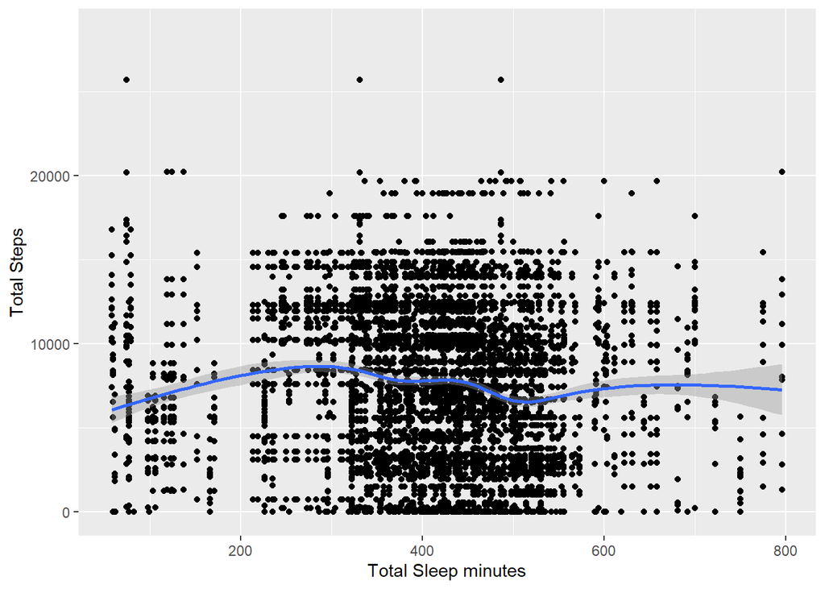

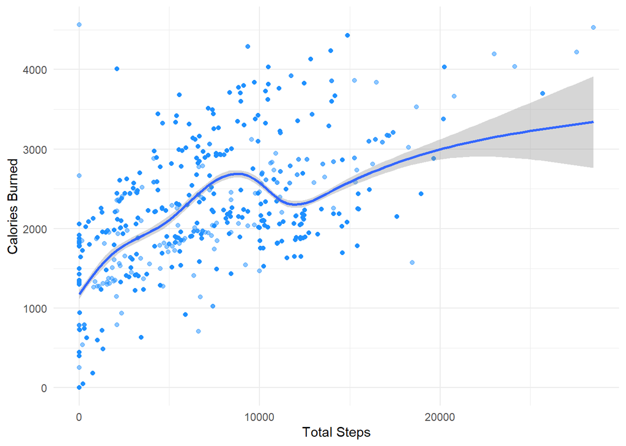

- As steps increase, more calories gets burnt.

```r
sleep_analysis <- combined_data %>% filter(!is.na(TotalTimeInBed)) %>%
  mutate(SleepEfficiency = TotalMinutesAsleep / TotalTimeInBed * 100) %>%
  arrange(Id, ActivityDate) %>% group_by(Id)
sleep_analysis
```

```
## # A tibble: 5,388 × 19
## # Groups:   Id [24]
##            Id SleepDay            TotalSleepRecords TotalMinutesAsleep
##         <dbl> <dttm>                          <int>              <int>
##  1 1503960366 2016-04-12 00:00:00                 1                327
##  2 1503960366 2016-04-13 00:00:00                 2                384
##  3 1503960366 2016-04-15 00:00:00                 1                412
##  4 1503960366 2016-04-16 00:00:00                 2                340
##  5 1503960366 2016-04-17 00:00:00                 1                700
##  6 1503960366 2016-04-19 00:00:00                 1                304
##  7 1503960366 2016-04-20 00:00:00                 1                360
##  8 1503960366 2016-04-21 00:00:00                 1                325
##  9 1503960366 2016-04-23 00:00:00                 1                361
## 10 1503960366 2016-04-24 00:00:00                 1                430
## # ℹ 5,378 more rows
## # ℹ 15 more variables: TotalTimeInBed <int>, ActivityDate <dttm>,
## #   TotalSteps <int>, TotalDistance <dbl>, TrackerDistance <dbl>,
## #   LoggedActivitiesDistance <dbl>, VeryActiveDistance <dbl>,
## #   ModeratelyActiveDistance <dbl>, LightActiveDistance <dbl>,
## #   VeryActiveMinutes <int>, FairlyActiveMinutes <int>,
## #   LightlyActiveMinutes <int>, SedentaryMinutes <int>, Calories <int>, …
```

- Calculating sleep efficiency, arranging through id, date and grouping by Id. filter!is.na() is used keep only rows where TotalTimeinBed column has a number.

Understanding sleep quality of the users.

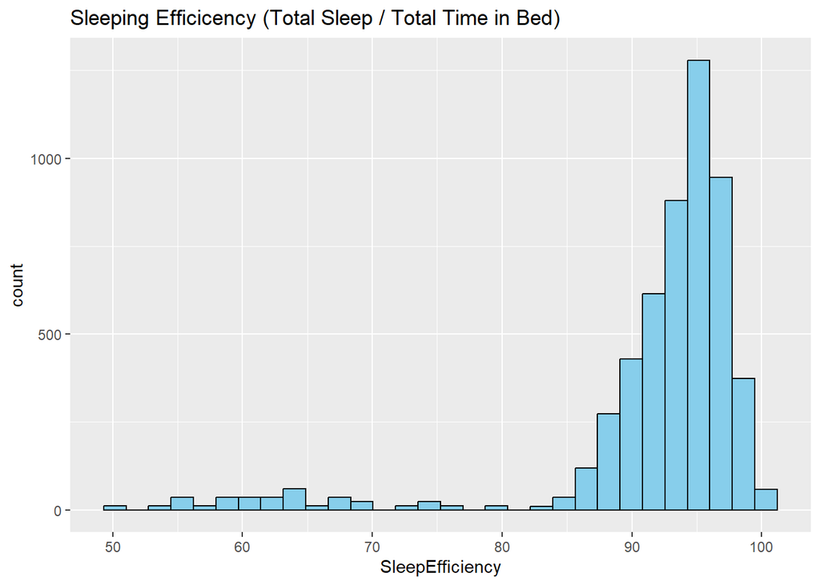

- Overall many users sleep quality is good and had efficient sleep.

```r
new_sleep_analysis <- sleep_analysis %>% mutate(Days0fWeek = factor(weekdays(SleepDay), levels = c('Monday', 'Tuesday', 'Wednesday', 'Thrusday', 'Friday', 'Saturday')))
```

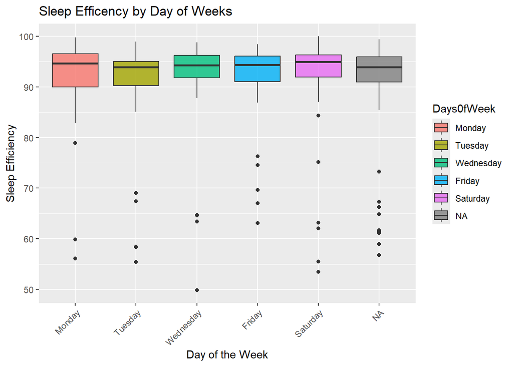

```r
new_intensities <- intensities %>% mutate(HourofDay = as.numeric(format(ActivityHour, "%H")))
```

A new column, Hour of Day was added to analyse the participants energy intensities across different hours of the day.

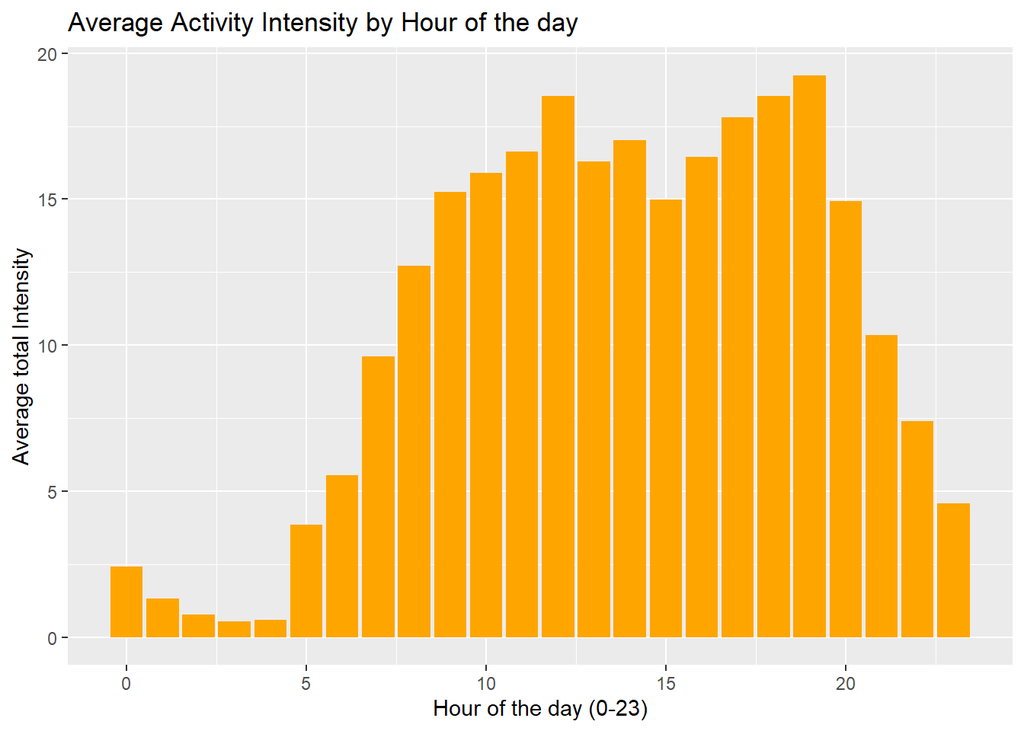

- The visual shows that people are active between 5 a.m. to 11 p.m.

## Summary of the Business Case Study.

Analyzing FitBit Fitness Tracker Data, can help BellaBeat to understand the audience and implement market strategy.

**Target audience**

Women who work full-time jobs and spend a lot of time at the computer, in a meeting, focused on work.

These women do some light activity to stay healthy. Even though they need to improve their everyday activity to have health benefits. They might need some knowledge about developing healthy habits or motivation to keep going.

- As there is no gender information about the participants, I assumed that all genders were presented and balanced in this data set.

**Recommendation for the Bellabeat.**

1. Steps of users should increase, Average steps should be more than 8000, taking 8000 steps per day was associated with a 51% lower risk for all-cause mortality.
2. Participants takes good amount of sleep, Bellabeat should consider using notification to go to sleep.
3. I recommend is that according to user’s BMI Bellabeat should display there weight category in app. And if category is overweight and obese Bellabeat should suggest to control diet and do exercise.
4. Sedentary min. is 995.3 min. means 16 hours, it should be reduced. Bellabeat should set some time for sedentary minutes, so after crossing it app will notify users to reduce their sedentary time.